# Stat 315, Final Report: Beijing Traded Houses Between 2002 and 2018

Kaili Chen

kailic

Due Friday, June 28, 2019 at 11:59 pm

```r
###########################
# PUT YOUR LIBRARIES HERE
###########################
library(tidyverse)
library(pander)
library(kableExtra)
library(knitr)
library(gridExtra)
```

# Introduction

Housing price one of the most commonplace topics for people who live in populous cities (see link attached below). I happened to find this dataset from Kaggle, on the traded house in Beijing. With an interest of exploring factors affecting housing prices and learning regional differences of housing types and building structures across districts, I decided to use this dataset for my final project.

(https://www.worldatlas.com/articles/the-10-largest-cities-in-the-world.html)

```r
beijing_original <- read_csv("/Users/kailichen/Documents/Carnegie\ Mellon\ University/36315\ Statistical\ Graphics\ and\ Visualization/Beijing/beijing\ housing\ price.csv")
beijing <- beijing_original %>% select(., Lng, Lat, subway, district,
                              totalPrice, price, square,
                              tradeTime, constructionTime,
                              buildingStructure, buildingType,
                              elevator, renovationCondition)

# some rows have an unknown character in the constructionTime column
# I decided to truncate these rows since I have no ways to interpret them
beijing <- beijing %>% filter(., constructionTime >= 1914 & constructionTime <= 2016)

beijing <- na.omit(beijing)

beijing <- beijing %>% mutate(
  subway = fct_recode(factor(subway),
                        "Yes" = "1",
                        "No" = "0"),
  elevator = fct_recode(factor(elevator),
                        "Yes" = "1",
                        "No" = "0"),
  buildingType = fct_recode(factor(buildingType),
                            "tower" = "1",
                            "bungalow" = "2",
                            "combination of plate and tower" = "3",
                            "plate" = "4"),
  renovationCondition = fct_recode(factor(renovationCondition),
                                   "Hardcover" = "4",
                                   "Simplicity" = "3",
                                   "Rough" = "2",
                                   "Other" = "1"),
  buildingStructure = fct_recode(factor(buildingStructure),
                                 "steel-concrete composite" = "6",
                                 "steel" = "5",
                                 "brick and concrete" = "4",
                                 "brick and wood" = "3",
                                 "mixed" = "2",
                                 "unknown" = "1"),
  district = fct_recode(factor(district),
                        "Dongcheng" = "1",
                        "Fengtai" = "2",
                        "Tongzhou" = "3",
                        "Daxing" = "4",
                        "Fangshan" = "5",
                        "Changping" = "6",
                        "Chaoyang" = "7",
                        "Haidian" = "8",
                        "Shijingshan" = "9",
                        "Xicheng" = "10",
                        "Pinggu" = "11",
                        "Mentougou" = "12",
                        "Shunyi" = "13"))

beijing$location = fct_recode(factor(beijing$district),
                   "Central District" = "Dongcheng",
                   "Central District" = "Xicheng",
                   "Middle" = "Chaoyang",
                   "Middle" = "Fengtai",
                   "Middle" = "Shijingshan",
                   "Middle" = "Haidian",
                   "Suburb" = "Daxing",
                   "Suburb" = "Fangshan",
                   "Suburb" = "Tongzhou",
                   "Suburb" = "Changping",
                   "Suburb" = "Pinggu",
                   "Suburb" = "Mentougou",
                   "Suburb" = "Shunyi")

# Did some transformation so that the final unit is in k rmb(Chinese Currency)
beijing$totalPrice = beijing$totalPrice * 10000 / 1000
beijing$tradeTime = as.Date(beijing$tradeTime)
```

### Data

```r
beijing %>% head() %>% pander()
```

Table continues below

| Lng | Lat | subway | district | totalPrice | price | square | tradeTime |
| --- | --- | --- | --- | --- | --- | --- | --- |
| 116.5 | 40.02 | Yes | Chaoyang | 4150 | 31680 | 131 | 2016-08-09 |
| 116.5 | 39.88 | No | Chaoyang | 5750 | 43436 | 132.4 | 2016-07-28 |
| 116.6 | 39.88 | No | Chaoyang | 10300 | 52021 | 198 | 2016-12-11 |
| 116.4 | 40.08 | No | Changping | 2975 | 22202 | 134 | 2016-09-30 |
| 116.4 | 39.89 | Yes | Dongcheng | 3920 | 48396 | 81 | 2016-08-28 |
| 116.5 | 39.99 | No | Chaoyang | 2756 | 52000 | 53 | 2016-07-22 |

Table continues below

| constructionTime | buildingStructure | buildingType | elevator |
| --- | --- | --- | --- |
| 2005 | steel-concrete composite | tower | Yes |
| 2004 | steel-concrete composite | tower | Yes |
| 2005 | steel-concrete composite | plate | Yes |
| 2008 | steel-concrete composite | tower | Yes |
| 1960 | mixed | plate | No |
| 2005 | steel-concrete composite | plate | Yes |

| renovationCondition | location |
| --- | --- |
| Simplicity | Middle |
| Hardcover | Middle |
| Simplicity | Middle |
| Other | Suburb |
| Rough | Central District |
| Simplicity | Middle |

The dataset originally has 318851 observations and 26 variables. After selecting several variables I am interested in and removing rows with unknown characters and rows containing NA values, the dataset I am analyzing in this project is reduced to 297990 observations with 14 variables:

| Column Name | Description |
| --- | --- |
| Lng | longitude coordinates |
| Lat | latitude coordinates |
| totalPrice | the total price(¥) |
| price | the price of the house (¥/$m^2$) |
| square | the area of house ($m^2$) |
| subway | located close to the subway or not |
| renovationCondition | hardcover, simplicity, rough, and other |
| buildingStructure | brick and wood, brick and concrete, steel, steel-concrete composite, mixed, unknown |
| buildingType | tower, plate&tower, plate, and bungalow |
| constructionTime | when was this house constructed |
| tradeTime | when was this house being sold |
| district | the district in which this listing is located |
| location | central district, middle, or suburb |

### Goals

- Write a 3-5 sentence paragraph that explains your overall analysis goal is (what are you trying to explore? which relationships do you think exist?).

My goal for this project is to analyze how different features or variables related to houses are related with the housing price. Moreover, I am also interested in looking at the geographical distribution of building types and building structures in the city and how they relate to each other. I think there is a relationship between subway and housing price (unit price and total price), between elevator and housing price (unit price and total price). I also think there is a relationship between location and building types, between location and building structures and between building types and builidng structures.

### Exploring the variables

Now, **for each variable**:

- Create a graph that summarizes its marginal distribution. Feel free to display multiple graphs at a time, keeping in mind the overall aesthetics of your report.
- Describe the graphs (1-2 sentences for each variable).

**Note:** You may want to include some simple, bivariate graphs. This could show any clear relationships that you’ll explore further below or show that, for example, many of your variables are highly correlated.

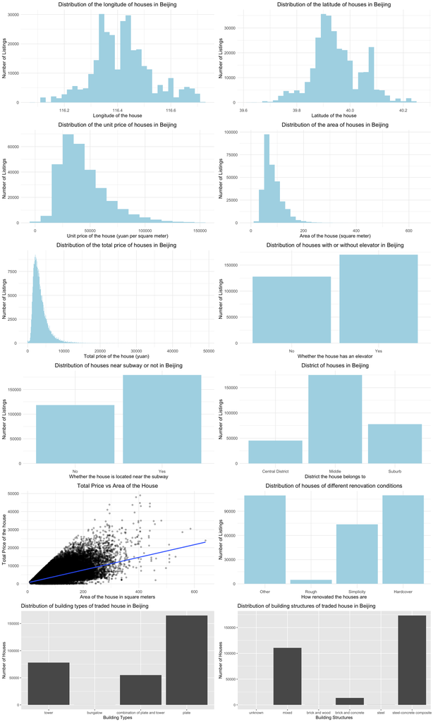

```r
my_theme <- theme_minimal() +
  theme(plot.title = element_text(hjust = 0.5, size = 14),
        axis.title = element_text(size = 12),
        axis.text = element_text(size = 10),
        legend.title = element_text(size = 12),
        legend.text = element_text(size = 10),
        strip.text = element_text(size = 10))

Lng <- ggplot(beijing, aes(x = Lng)) +
  geom_histogram(fill = "lightblue", binwidth = 0.02) +
  labs(title = "Distribution of the longitude of houses in Beijing",
       x = "Longitude of the house",
       y = "Number of Listings") +
  my_theme

Lat <- ggplot(beijing, aes(x = Lat)) +
  geom_histogram(fill = "lightblue", binwidth = 0.02) +
  labs(title = "Distribution of the latitude of houses in Beijing",
       x = "Latitude of the house",
       y = "Number of Listings") +
  my_theme

Price <- ggplot(beijing, aes(x = price)) +
  geom_histogram(fill = "lightblue", binwidth = 10000) +
  labs(title = "Distribution of the unit price of houses in Beijing",
       x = "Unit price of the house (yuan per square meter)",
       y = "Number of Listings") +
  my_theme

Square <- ggplot(beijing, aes(x = square)) +
  geom_histogram(fill = "lightblue", binwidth = 20) +
  labs(title = "Distribution of the area of houses in Beijing",
       x = "Area of the house (square meter)",
       y = "Number of Listings") +
  my_theme

TotalPrice <- ggplot(beijing, aes(x = totalPrice)) +
  geom_histogram(fill = "lightblue", binwidth = 100) +
  labs(title = "Distribution of the total price of houses in Beijing",
       x = "Total price of the house (yuan)",
       y = "Number of Listings") +
  my_theme

Elevator <- ggplot(beijing, aes(x = elevator)) +
  geom_bar(fill = "lightblue") +
  labs(title = "Distribution of houses with or without elevator in Beijing",
       x = "Whether the house has an elevator",
       y = "Number of Listings") +
  my_theme

Subway <- ggplot(beijing, aes(x = subway)) +
  geom_bar(fill = "lightblue") +
  labs(title = "Distribution of houses near subway or not in Beijing",
       x = "Whether the house is located near the subway",
       y = "Number of Listings") +
  my_theme

Location <- ggplot(beijing, aes(x = location)) +
  geom_bar(fill = "lightblue") +
  labs(title = "District of houses in Beijing",
       x = "District the house belongs to",
       y = "Number of Listings") +
  my_theme

RenovationCondition <- ggplot(beijing, aes(x = renovationCondition)) +
  geom_bar(fill = "lightblue") +
  labs(title = "Distribution of houses of different renovation conditions",
       x = "How renovated the houses are",
       y = "Number of Listings") +
  my_theme

tprice_square <- ggplot(beijing, aes(x = square, y = totalPrice)) +
  geom_point(alpha = 0.3) +
  geom_smooth(method = lm, se = FALSE) +
  labs(title = "Total Price vs Area of the House",
       x = "Area of the house in square meters",
       y = "Total Price of the house") +
  my_theme

TradeTime <- ggplot(beijing, aes(x = tradeTime)) +
  geom_histogram(binwidth = 120) +
  scale_x_date(date_breaks = "2 year", date_labels = "%y")


BuildingType <- ggplot(beijing, aes(x = buildingType)) +
  geom_bar() +
  labs(title = "Distribution of building types of traded house in Beijing",
       x = "Building Types",
       y = "Number of Houses")

BuildingStructure <- ggplot(beijing, aes(x = buildingStructure)) +
  geom_bar() +
  labs(title = "Distribution of building structures of traded house in Beijing",
       x = "Building Structures",
       y = "Number of Houses")

grid.arrange(Lng, Lat, Price, Square, TotalPrice, Elevator,
             Subway, Location, tprice_square, RenovationCondition,
             BuildingType, BuildingStructure,
             nrow = 6, ncol = 2)
```

# Methods

Hypothesis 1: Houses that are close to the subway were traded on average at a higher price than houses that are not close to the subway.

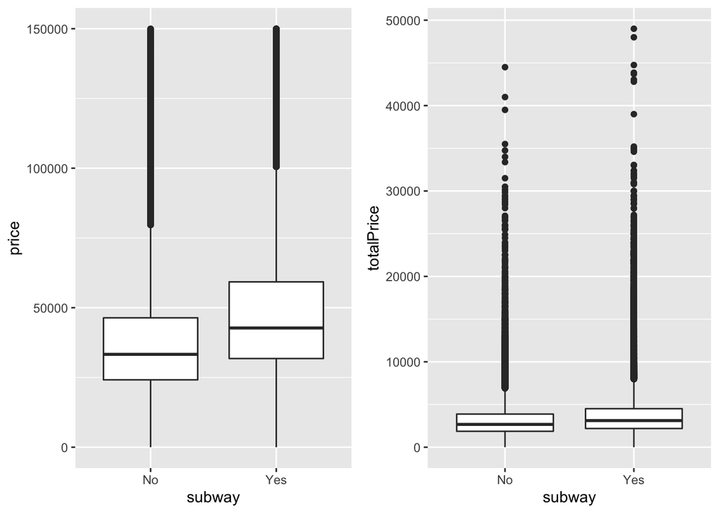

```r
price_subway <- colMeans(beijing[which(beijing$subway == 1), "price"])
price_nosubway <- colMeans(beijing[which(beijing$subway == 0), "price"])


tprice_subway <- colMeans(beijing[which(beijing$subway == 1), "totalPrice"])
tprice_nosubway <- colMeans(beijing[which(beijing$subway == 0), "totalPrice"])


# use boxplot
subway_price <- ggplot(beijing, aes(x = subway, y = price)) +
                geom_boxplot()

subway_totalprice <- ggplot(beijing, aes(x = subway, y = totalPrice)) +
                     geom_boxplot()
grid.arrange(subway_price, subway_totalprice, nrow = 1)
```

```r
subway_price = mean(beijing$price[which(beijing$subway == "Yes")])
nosubway_price = mean(beijing$price[which(beijing$subway == "No")])
subway_price - nosubway_price
```

```
## [1] 10276.92
```

```r
subway_tprice = mean(beijing$totalPrice[which(beijing$subway == "Yes")])
nosubway_tprice = mean(beijing$totalPrice[which(beijing$subway == "No")])
subway_tprice - nosubway_tprice
```

```
## [1] 535.9719
```

To test if my hypothesis is true, I made first made a side-by-side boxplot to compare the unit price of houses located near the subway with houses located far from the subway (the graph on the left). We can tell that the mean of unit price for houses located near the subway is higher than houses located far away from the subway, and they differ by 10276.92 RMB/$m^2$. Then I made a similar side-by-side boxplot but this time I wanted to compare the total price of houses located near the subway with that of houses located far from the subway. We can tell that the mean of total price for houses located near the subway is higher than houses located far away from the subway, and they differ by 535971.9 RMB.

Hypothesis 2: I think houses in the same district have similar renovation conditions inside of the house.

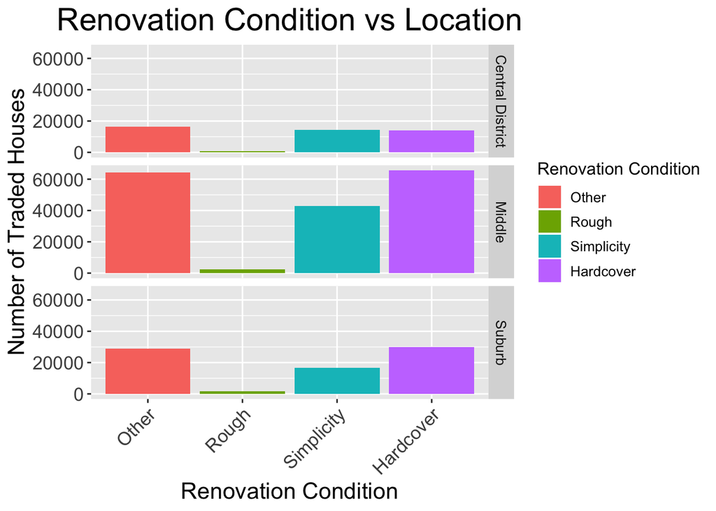

```r
ggplot(beijing,
       aes(x = renovationCondition,
           fill = as.factor(renovationCondition))) +
  geom_bar(position = "dodge") +
  facet_grid(location ~ . ) +
  theme(axis.text.x = element_text(angle = 45, hjust = 1)) +
  labs(x = "Renovation Condition",
       y = "Number of Traded Houses",
       title = "Renovation Condition vs Location",
       fill = "Renovation Condition") +
       theme(plot.title = element_text(hjust = 0.5, size = 22),
       axis.title = element_text(size = 16),
       axis.text = element_text(size = 13),
       legend.title = element_text(size = 12),
       legend.text = element_text(size = 10),
       strip.text = element_text(size = 10))
```

I created three bar charts on the distribution of houses under different renovation conditions, and then I facet them by district to see if there is any difference in different district. My understanding of hardcover, simplicity and rough are houses that are highly renovated and completely furnished, houses that are simply renovated and houses that are barely furnished. As we can see, in central district, there are about similar amount of houses that are highly renovated and houses that are simply renovated. Whereas in the middle area and suburb of Beijing, there are more houses that are highly renovated and completely furnished than houses that are simply renovated. One common thing across all districts is that there are very few houses that are barely furnished or renovated. It makes sense because in such a fast-paced city, there will be a very small market for people who look for houses that are not furnished before moving in.

Hypothesis 3: I think on average unit price increases as the location gets closer to the Central Business District (CBD) of Beijing.

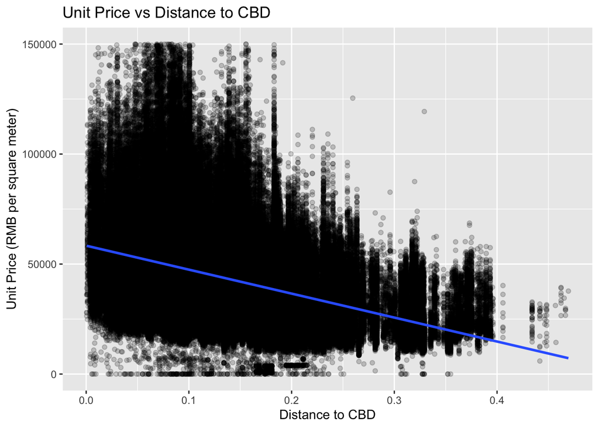

```r
beijing$distance_cbd = sqrt((beijing$Lng - 116.4438059)^2 +
                              (beijing$Lat - 39.9038734)^2)

ggplot(beijing, aes(x = distance_cbd, y = price)) +
  geom_point(alpha = 0.2) +
  geom_smooth(method = "lm", se = FALSE) +
  labs(x = "Distance to CBD", y = "Unit Price (RMB per square meter)",
       title = "Unit Price vs Distance to CBD")
```

To measure how far each house is away from the center of Beijing, I compute their distances with the coordinates of a point in the central business district of Beijing and saved the distances in a column called `distance_cbd`. After that, I created a scatterplot on price vs distance to CBD (Central Business District) and I added a best fit line to the scatterplot. Since the best-fit linear line has a downward slope, I believe we have enough evidence to conclude that on average, as the distance of the house to CBD increases, housing price on average would decrease.

Hypothesis 4: I think houses with an elevator are associated with a higher unit price for houses across all district in Beijing.

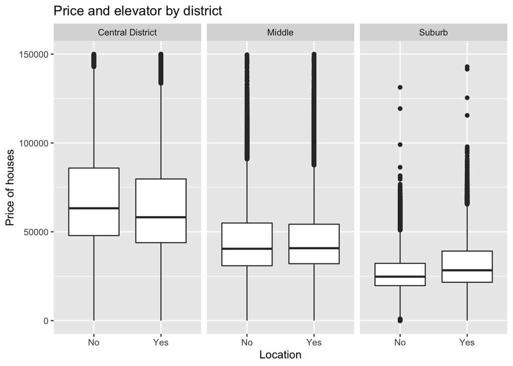

```r
ggplot(beijing,
       aes(x = elevator,
           y = price)) +
  facet_grid(. ~ location) +
  geom_boxplot() +
  labs(x = "Location",
       y = "Price of houses",
       title = "Price and elevator by district")
```

I created three side-by-side boxplots comparing the unit price of houses with an elevator in the building and houses without an elevator, and then I facet the houses by district, to see if there are any regional differences. The result is quite interesting. In central business district, houses with an elevator on average have a lower unit price than houses without an elevator. In the district in between central district and suburb of Beijing, houses with an elevator on average have a similar unit price than houses without an elevator. On the contrary, for houses in the suburb of Beijing, houses with an elevator on average have a higher unit price than houses without an elevator, as I assumed in my hypothesis.

Hypothesis 5:

Houses with a relatively high unit price (greater than 140000 RMB per square meter) are located together, so does houses with a relatively low unit price (less than 5000 RMB per square meter).

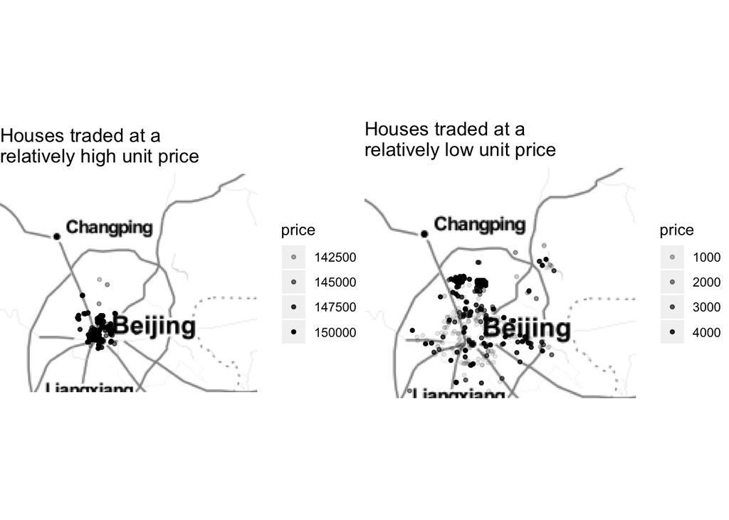

```r
library(ggmap)

beijing_coord <- c(bottom = 39.35 + 0.4, left = 115 + 1,
                   top = 41 - 0.6, right = 118 - 1)

map_base <- get_stamenmap(beijing_coord, maptype = "toner-lite", zoom = 8)

map_object <- ggmap(map_base, extent = "device")

beijing_highprice <- beijing %>% filter(. , price > 140000)

high_price_loc <- map_object + geom_point(aes(x = Lng, y = Lat, alpha = price),
                        data = beijing_highprice, size = 1) +
             labs(x = "",
                  y = "",
                  title = "Houses traded at a \nrelatively high unit price")

beijing_lowprice <- beijing %>% filter(. , price < 5000)

low_price_loc <- map_object + geom_point(aes(x = Lng, y = Lat, alpha = price),
                        data = beijing_lowprice, size = 1) +
             labs(x = "",
                  y = "",
                  title = "Houses traded at a \nrelatively low unit price")
grid.arrange(high_price_loc, low_price_loc, nrow = 1)
```

I plotted the geographical location of houses with relatively high unit price, with transparency. The darker the color is, the more expensive the unit price of the house is. I also plotted the geographical location of houses with relatively low unit price, with transparency. Same as the previous graph, the darker the color is, the more expensive the unit price of the house is. From the first graph, we can see that houses traded at a relatively high unit price are clustered in the center of Beijing, with a few houses located somewhere in between the CBD and the suburb. On the contrary, houses traded at a relatively low unit price are spread out pretty evenly across all district in Beijing, with a cluster to the north of CBD.

Hypothesis 6: there is some relationship between building structure and building type.

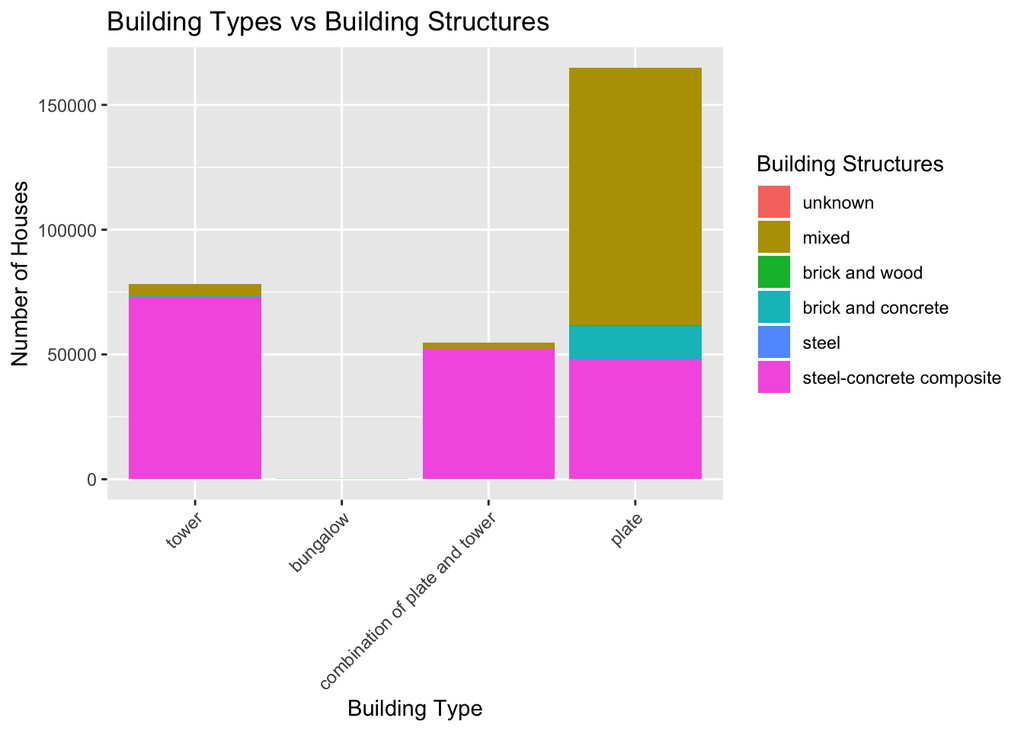

```r
ggplot(beijing, aes(x = buildingType)) +
  geom_bar(aes(fill = buildingStructure)) +
  theme(axis.text.x = element_text(angle = 45, hjust = 1)) +
  labs(x = "Building Type",
       y = "Number of Houses",
       fill = "Building Structures",
       title = "Building Types vs Building Structures")
```

To see whethere there are any relationship between two categorical variables building types and building structures, I plotted a stacked bar chart of houses of different building types, colored by different building structures. Some interesting takeaway from this graph is that most tower buildings and buildings made of the combination of plate and tower are steel-concrete composite. Most plate buildings are mixed in terms of building structure, and the next common building structure for plate buildings is steel-concrete composite, followed by brick and concrete building structure.

# Results

# Discussion

Geographically, Beijing has this interesting shape of roads – five rings on a map marked by major roads. It would be interesting to explore whether housing price all shows a five-ring pattern, highest in the middle and then keep decreasing as the ring gets bigger.

One of the biggest limiation of my data analysis is that I haven’t had the chance to explore all the 26 variables and how different variables relate to each other. For example, there is a column in the originla dataset called “floor”, that indicates the floor of the house. I would like to know the relative height of the house with regard to the building, low, middle, or high.